# Technology Design for *Epistemic Niche Construction*

in the AI Era

Bodong Chen • 陈伯栋

cbd@upenn.edu • bchen.net

Associate Professor, University of Pennsylvania  
**KBSI 2026, Nanjing, China**

## Next-Generation KB Environments (2011)

### 下一代知识建构环境（2011）

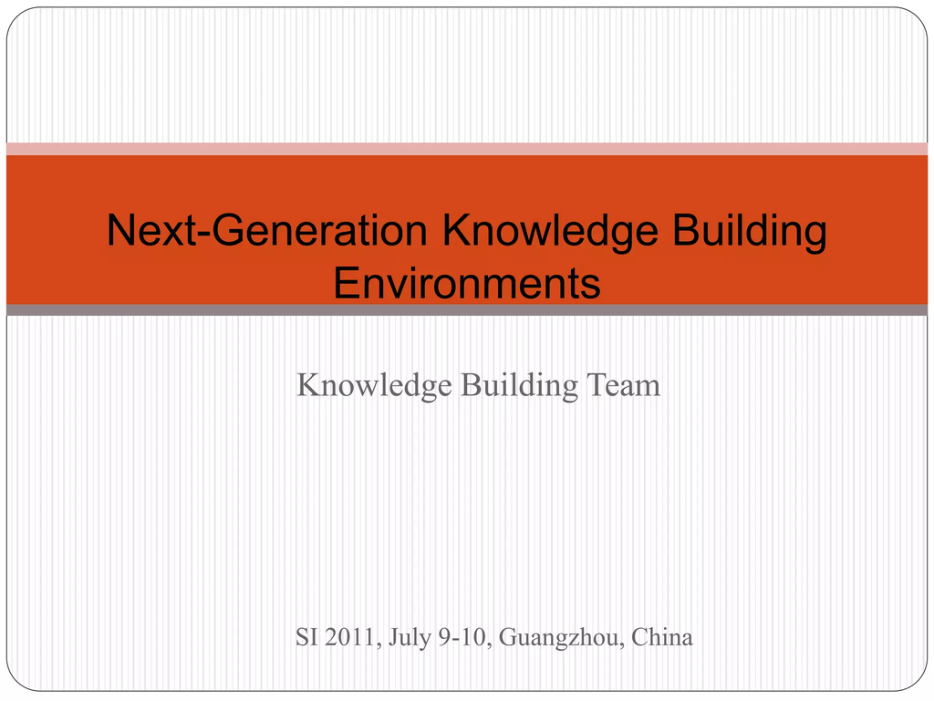

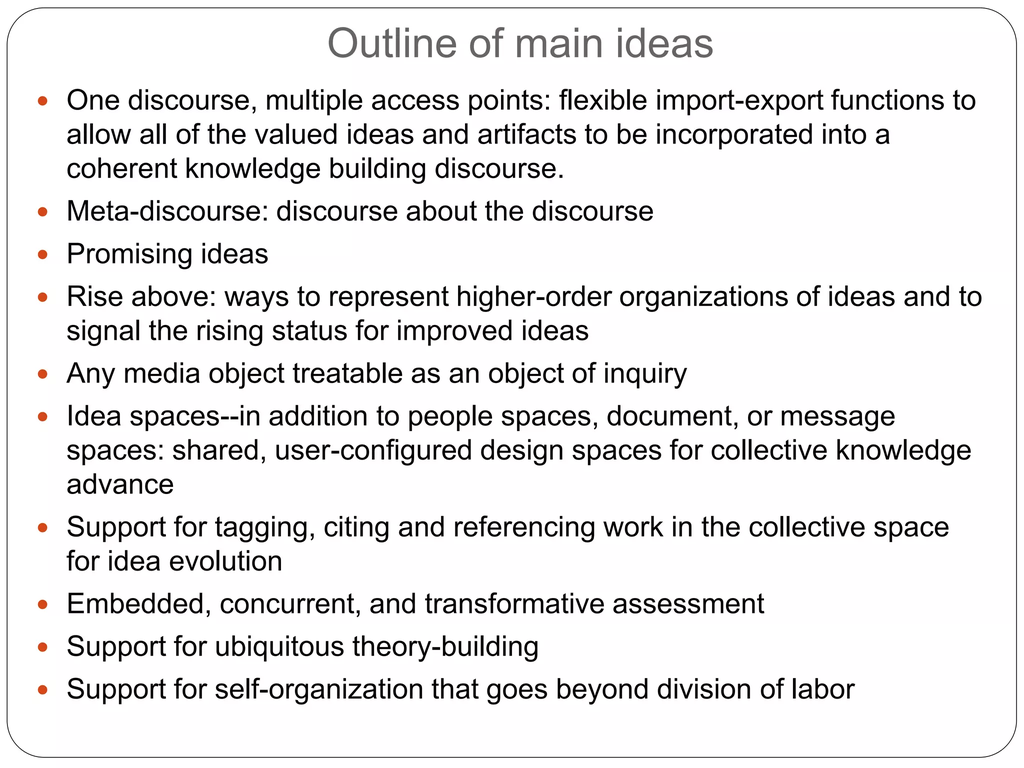

## Technology Design for Knowledge Building

### 设计服务于知识建构的技术

Not an engineering problem.

A **pedagogical, philosophical, and aesthetic** problem.

To nurture a sense of **“feeling at home”** when working with ideas

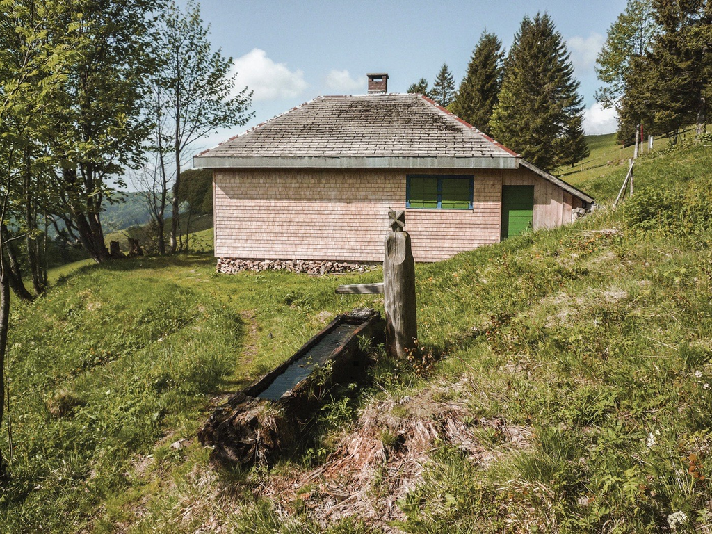

Photo: [Heidegger’s hut](https://thinkingplace.org/heidegger/)

## Technology is Never Neutral

### 技术从来不是中立的

> “**Technology is not neutral.** Each technology has properties—**affordances**—that make it easier to do some activities, harder to do others.” — Don Norman (2014)

> “**Architecture is a mediation between the world and our minds.** … The task of architecture is to **defend the autonomy of human experience**, not to condition, dominate or dictate.” — Juhani Pallasmaa (2018)

> “Can software be designed with **a bias toward high-road rather than low-road cognitive paths**?” — Scardamalia & Bereiter (2008, p. 4)

The question is: biased *toward what*?

## AI Raises the Stakes

### AI正引发深刻变革

- LLM inference is cheap
- From composing to evaluating
- Agentic AI acts on behalf of users
- LLM bias goes largely undetected or unchallenged
- Monocultures threaten epistemic diversity

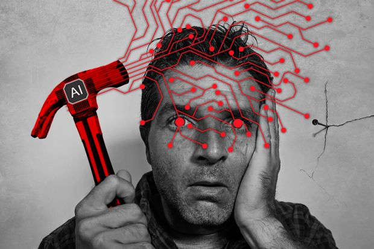

Human thinking is being quietly shaped by AI — from the inside out.

**Knowledge Building** — a beacon for cultivating “high-road cognitive paths” in education — has a vital role to play.

In the AI era, a new goal we should pursue is to empower *epistemic niche construction* by learners.

This is a bias we should ultimately build into next-generation KB technology.

# Epistemic **Niche** Construction

[figure not shown]

## Niche construction: the original idea

### 生态位构建：概念的起源

**Niche**: the position of a species within its habitat

*Ecological* niche (生态位): the environmental conditions that permit the continued existence of a population (Hutchinson, 1957; Trappes, 2021)

**Niche construction**: organisms modify their environments, and those modifications feed back to reshape the organisms (Lewontin, 1983; Odling-Smee et al., 2003)

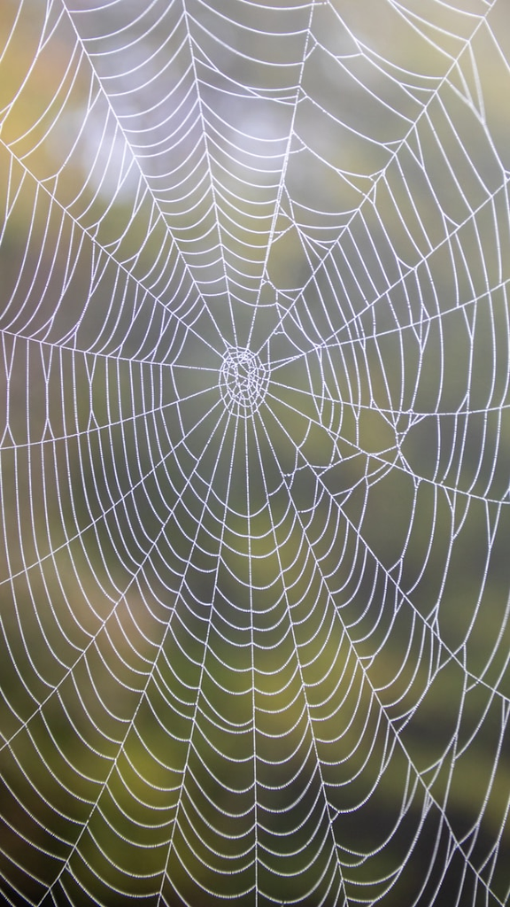

## Epistemic Niche Construction

### 认识生态位构建

**Epistemic niche** (认识生态位): the shared representations, practices, and values that a community constructs to support knowledge production.

**Epistemic niche construction**: building and modifying these conditions — and being **cognitively reshaped** by what is built.

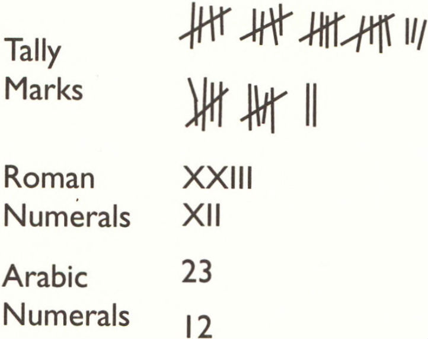

Sterelny (2010, 2012); Norman (1993);  
Kuhn (1970); De Benedetto & Luchetti (2025)

## Epistemic Niche Construction

### 认识生态位构建

**Epistemic niche** (认识生态位): the shared representations, practices, and values that a community constructs to support knowledge production.

**Epistemic niche construction**: building and modifying these conditions — and being **cognitively reshaped** by what is built.

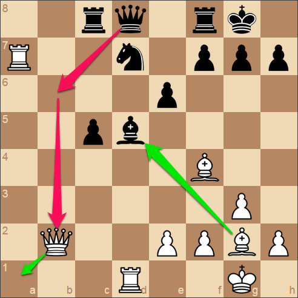

Sterelny (2010, 2012); Norman (1993);  
Kuhn (1970); De Benedetto & Luchetti (2025)

## Epistemic Niche Construction

### 认识生态位构建

**Epistemic niche** (认识生态位): the shared representations, practices, and values that a community constructs to support knowledge production.

**Epistemic niche construction**: building and modifying these conditions — and being **cognitively reshaped** by what is built.

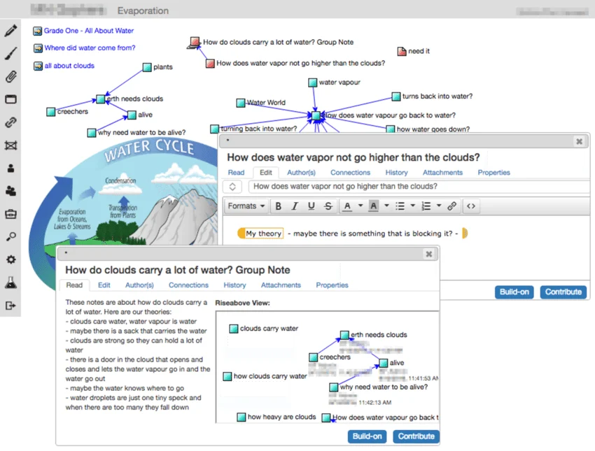

Sterelny (2010, 2012); Norman (1993);  
Kuhn (1970); De Benedetto & Luchetti (2025)

## From Epistemic Agency to Niche Construction

### 从认识主体性到生态位构建

**Epistemic agency**

*Acting within an epistemic environment*

- forming beliefs
- contributing ideas
- evaluating claims
- setting goals

**Epistemic niche construction**

*Shaping the epistemic environment itself*

- inventing representations
- creating tools
- establishing practices
- building infrastructures

## The new design question

### 新的设计问题

How does technology support knowledge building?

**How does technology support humans in constructing epistemic niches that sustain their knowledge building?**

- What roles should AI play in epistemic niche construction?

# 1. Construct Niche *With* AI

**利用AI构建和改善认识生态位**

Harness AI to enrich human epistemic niches.

## AI can enrich dimensions of an epistemic niche

### AI可以丰富认识生态位的各个维度

If an epistemic niche can be defined in multiple dimensions:

| Niche dimension | AI enhancement |
| --- | --- |
| **Symbolic representations** | Generate views of the same discourse (graphs, timelines, summaries) |
| **Practices** | Surface patterns that prompt meta-discourse and new inquiry moves |
| **Values** | Make epistemic standards visible and contestable |
| … | … |

## Example: Buzz in Wonderbits

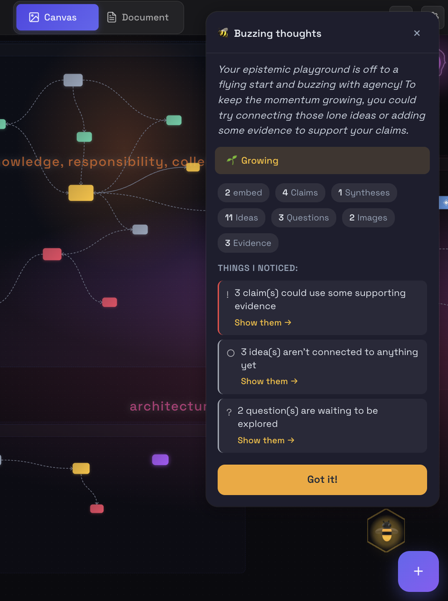

**Buzz** — an AI assistant that’s responsible for doing health checks of the knowledge space, and reports:

- orphaned ideas with no connections
- claims lacking evidence support
- questions no one has pursued
- clusters of ideas that could be bridged

Students decide what to act on.

# 2. Construct Niche *Against* AI

**加固生态位以防范AI的侵蚀**

Protect human epistemic niches against AI erosion.

## AI can erode opportunities to learn

### AI可能侵蚀本应发展的能力

When AI is used superficially as an “answer machine,” learners lose the very experience that builds their capacity.

An example (Bastani et al., 2025):

- Students using ChatGPT improved **48%** during practice
- But performed **17% worse** when ChatGPT was removed

The short-term gain masks a long-term loss.

```
%%{init: {'theme': 'default', 'themeVariables': {'fontSize': '24px'}}}%%
flowchart TD
    A["Superficial AI use"] --> B["Less learning"]
    B --> C["Weaker skills"]
    C --> A
```

## AI has limitations for epistemic tasks

### 明确AI的认识论局限

AI dispositions are embedded without lived experience—no embodiment, no emotion, no situated judgment.

These dispositions shape outputs in ways that often go **undetected and unchallenged**.

- LLM bias infiltrates reasoning quietly
- Shared models homogenize outputs (Doshi & Hauser, 2024)
- “Monocultures of knowing” emerge (Messeri & Crockett, 2024)

## Carbon-based thinking substrate needs protection

### 保护碳基的思考基质

| Dimension | **Carbon** (brain + body) | **Silicon** (weights + hardware) |
| --- | --- | --- |
| **Material & energy** | Metabolic; cognition coupled to bodily state | Electronic; no metabolic coupling |
| **Temporality** | Rhythmic: sleep, fatigue, incubation; millisecond timescales | Flat: no intrinsic rhythm; nanosecond timescales |
| **Embodiment** | Sensorimotor grounding | Disembodied token processing |
| **Finitude** | Forgetting, fatigue, death | Context window; disposition shaped by training |

Carbon constraints are **productive** for human learning. Offloading them to silicon removes the frictions that build expertise.

## Example: Pip in Wonderbits

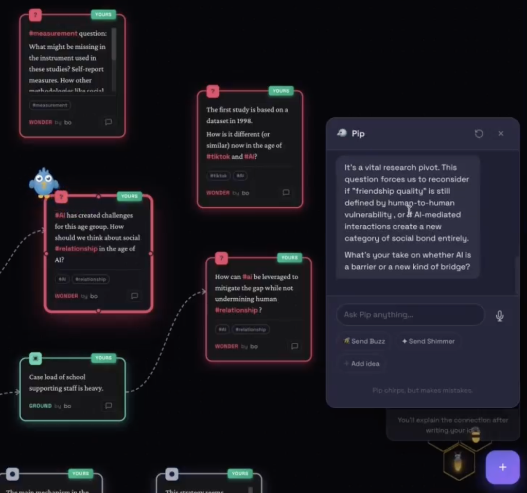

**Pip** — an AI assistant living on the knowledge canvas.

Core rule: **scaffold, don’t substitute**.

- AI is equipped with tools and can take actions. But students still need to think.
- ✅ “That’s an important question. What’s your take?”
- ✅ “Great point. Want me to capture that?”

AI has important roles to play in our efforts to build knowledge — and in the construction of epistemic niches.

Next-generation KB environments should empower learners (and teachers) to **construct their own epistemic niches** — the representations, practices, and values through which knowledge is built.

In the agentic AI era, this is the defining challenge. **Supporting epistemic niche construction is a necessary step forward to enhance and protect epistemic agency in an AI-mediated world.**

## Key References

- Bastani, H., et al. (2025). Generative AI without guardrails can harm learning: Evidence from high school mathematics. *PNAS*.
- De Benedetto, M., & Luchetti, M. (2025). Epistemic niche construction and non-epistemic values. *European Journal for Philosophy of Science*.
- Doshi, A. R., & Hauser, O. P. (2024). Generative AI enhances individual creativity but reduces collective diversity. *Science Advances*.
- Kuhn, T. S. (1970). *The Structure of Scientific Revolutions* (2nd ed.). University of Chicago Press.
- Messeri, L., & Crockett, M. J. (2024). AI and illusions of understanding. *Nature*.
- Norman, D. A. (1993). *Things That Make Us Smart*. Addison-Wesley.
- Odling-Smee, F. J., Laland, K. N., & Feldman, M. W. (2003). *Niche Construction: The Neglected Process in Evolution*. Princeton UP.
- Scardamalia, M., & Bereiter, C. (2008). Pedagogical biases in educational technologies. *Educational Technology*.
- Sterelny, K. (2010). Minds: extended or scaffolded? *Phenomenology and the Cognitive Sciences*.
- Tankelevitch, L., et al. (2024). Metacognitive demands of generative AI. *CHI 2024*.
- Thagard, P. (2022). Energy requirements undermine substrate independence. *Philosophy of Science*.
- Trappes, R. (2021). Defining the niche for niche construction. *Biology & Philosophy*.